# Practicum 3- Plants

#### Author: Smriti Bajaj

### 1. Inspect the Plant Catalog XML

Here, plants.xml is being parsed using xmlParse() function that comes with the “XML” package. It parses a valid XML and beautifies it.

```r
# Load the package required to read XML files.
if(!require("XML")) install.packages("XML")
library("XML")

# Give the input file name- "plants.xml" to the function.
result <- xmlParse(file = "plants.xml")

# Print the result.
print(result)
```

```
## <?xml version="1.0"?>
## <CATALOG>
##   <PLANT>
##     <COMMON>Bloodroot</COMMON>
##     <BOTANICAL>Sanguinaria canadensis</BOTANICAL>
##     <ZONE>4</ZONE>
##     <LIGHT>Mostly Shady</LIGHT>
##     <PRICE>$2.44</PRICE>
##     <AVAILABILITY>031599</AVAILABILITY>
##   </PLANT>
##   <PLANT>
##     <COMMON>Columbine</COMMON>
##     <BOTANICAL>Aquilegia canadensis</BOTANICAL>
##     <ZONE>3</ZONE>
##     <LIGHT>Mostly Shady</LIGHT>
##     <PRICE>$9.37</PRICE>
##     <AVAILABILITY>030699</AVAILABILITY>
##   </PLANT>
##   <PLANT>
##     <COMMON>Marsh Marigold</COMMON>
##     <BOTANICAL>Caltha palustris</BOTANICAL>
##     <ZONE>4</ZONE>
##     <LIGHT>Mostly Sunny</LIGHT>
##     <PRICE>$6.81</PRICE>
##     <AVAILABILITY>051799</AVAILABILITY>
##   </PLANT>
##   <PLANT>
##     <COMMON>Cowslip</COMMON>
##     <BOTANICAL>Caltha palustris</BOTANICAL>
##     <ZONE>4</ZONE>
##     <LIGHT>Mostly Shady</LIGHT>
##     <PRICE>$9.90</PRICE>
##     <AVAILABILITY>030699</AVAILABILITY>
##   </PLANT>
##   <PLANT>
##     <COMMON>Dutchman's-Breeches</COMMON>
##     <BOTANICAL>Dicentra cucullaria</BOTANICAL>
##     <ZONE>3</ZONE>
##     <LIGHT>Mostly Shady</LIGHT>
##     <PRICE>$6.44</PRICE>
```

[output cut: 237 more lines]

```
##     <ZONE>Annual</ZONE>
##     <LIGHT>Shade</LIGHT>
##     <PRICE>$5.63</PRICE>
##     <AVAILABILITY>071199</AVAILABILITY>
##   </PLANT>
##   <PLANT>
##     <COMMON>Cardinal Flower</COMMON>
##     <BOTANICAL>Lobelia cardinalis</BOTANICAL>
##     <ZONE>2</ZONE>
##     <LIGHT>Shade</LIGHT>
##     <PRICE>$3.02</PRICE>
##     <AVAILABILITY>022299</AVAILABILITY>
##   </PLANT>
## </CATALOG>
##
```

### 2. Load the Plant Catalog XML into a dataframe using xmlToDataFrame

xmlToDataFrame() function is available from “XML” package which transforms an XML document to a data frame. A data frame is a table or a two-dimensional array-like structure in which each column contains values of one variable/element(in XML) and each row contains one set of values from each column.

```r
#loading the XML
xmlDataFrame <- xmlToDataFrame("plants.xml")

# print the data frame
xmlDataFrame
```

| COMMON | BOTANICAL | ZONE | LIGHT | PRICE | AVAILABILITY |
| --- | --- | --- | --- | --- | --- |
| Bloodroot | Sanguinaria canadensis | 4 | Mostly Shady | $2.44 | 031599 |
| Columbine | Aquilegia canadensis | 3 | Mostly Shady | $9.37 | 030699 |
| Marsh Marigold | Caltha palustris | 4 | Mostly Sunny | $6.81 | 051799 |
| Cowslip | Caltha palustris | 4 | Mostly Shady | $9.90 | 030699 |
| Dutchman's-Breeches | Dicentra cucullaria | 3 | Mostly Shady | $6.44 | 012099 |
| Ginger, Wild | Asarum canadense | 3 | Mostly Shady | $9.03 | 041899 |
| Hepatica | Hepatica americana | 4 | Mostly Shady | $4.45 | 012699 |
| Liverleaf | Hepatica americana | 4 | Mostly Shady | $3.99 | 010299 |
| Jack-In-The-Pulpit | Arisaema triphyllum | 4 | Mostly Shady | $3.23 | 020199 |
| Mayapple | Podophyllum peltatum | 3 | Mostly Shady | $2.98 | 060599 |

[output cut: 26 more lines]

### 3. Creating a column “RETAIL”

Creation of a column in a dataframe can be done by simply assigning value to it using a dollar symbol ($) for reference of the column name. Here, as.numeric() function is used to convert a **string** into **double** type. Additionally, dollar symbol which is the first character in every Price string(row), is excluded from the string by using substring() function.

```r
#Stripping off the $ symbol from PRICE column
xmlDataFrame$RETAIL = as.numeric(substring(xmlDataFrame$PRICE,2))

xmlDataFrame
```

| COMMON | BOTANICAL | ZONE | LIGHT | PRICE | AVAILABILITY | RETAIL |
| --- | --- | --- | --- | --- | --- | --- |
| Bloodroot | Sanguinaria canadensis | 4 | Mostly Shady | $2.44 | 031599 | 2.44 |
| Columbine | Aquilegia canadensis | 3 | Mostly Shady | $9.37 | 030699 | 9.37 |
| Marsh Marigold | Caltha palustris | 4 | Mostly Sunny | $6.81 | 051799 | 6.81 |
| Cowslip | Caltha palustris | 4 | Mostly Shady | $9.90 | 030699 | 9.90 |
| Dutchman's-Breeches | Dicentra cucullaria | 3 | Mostly Shady | $6.44 | 012099 | 6.44 |
| Ginger, Wild | Asarum canadense | 3 | Mostly Shady | $9.03 | 041899 | 9.03 |
| Hepatica | Hepatica americana | 4 | Mostly Shady | $4.45 | 012699 | 4.45 |
| Liverleaf | Hepatica americana | 4 | Mostly Shady | $3.99 | 010299 | 3.99 |
| Jack-In-The-Pulpit | Arisaema triphyllum | 4 | Mostly Shady | $3.23 | 020199 | 3.23 |
| Mayapple | Podophyllum peltatum | 3 | Mostly Shady | $2.98 | 060599 | 2.98 |

[output cut: 26 more lines]

### 4. Removing the PRICE column

PRICE column since already has the data in newly created RETAIL column, to remove redundancy and ensure consistency in the data frame, subset() function is being used to delete the column.

**S3 method for class ‘data.frame’** subset(x, subset, select, drop = FALSE, …)

**Arguments**

x  
object to be subsetted.

subset  
logical expression indicating elements or rows to keep: missing values are taken as false.

select  
expression, indicating columns to select from a data frame.

drop  
passed on to [ indexing operator.

… further arguments to be passed to or from other methods.

```r
#deleting PRICE column
xmlDataFrame<- subset(xmlDataFrame, select=-PRICE)

xmlDataFrame
```

|  | COMMON | BOTANICAL | ZONE | LIGHT | AVAILABILITY | RETAIL |
| --- | --- | --- | --- | --- | --- | --- |
| 1 | Bloodroot | Sanguinaria canadensis | 4 | Mostly Shady | 031599 | 2.44 |
| 2 | Columbine | Aquilegia canadensis | 3 | Mostly Shady | 030699 | 9.37 |
| 3 | Marsh Marigold | Caltha palustris | 4 | Mostly Sunny | 051799 | 6.81 |
| 4 | Cowslip | Caltha palustris | 4 | Mostly Shady | 030699 | 9.90 |
| 5 | Dutchman's-Breeches | Dicentra cucullaria | 3 | Mostly Shady | 012099 | 6.44 |
| 6 | Ginger, Wild | Asarum canadense | 3 | Mostly Shady | 041899 | 9.03 |
| 7 | Hepatica | Hepatica americana | 4 | Mostly Shady | 012699 | 4.45 |
| 8 | Liverleaf | Hepatica americana | 4 | Mostly Shady | 010299 | 3.99 |
| 9 | Jack-In-The-Pulpit | Arisaema triphyllum | 4 | Mostly Shady | 020199 | 3.23 |
| 10 | Mayapple | Podophyllum peltatum | 3 | Mostly Shady | 060599 | 2.98 |

[output cut: 26 more lines]

### 5. Increase prices by 4.25%

A simple formula to increase the prices by 4.25 % is-

**New price = Old price + (Old price*4.25)/100**

```r
# increase Retail column values by 4.25% and update the same
xmlDataFrame$RETAIL=xmlDataFrame$RETAIL*(1+0.0425)

xmlDataFrame
```

|  | COMMON | BOTANICAL | ZONE | LIGHT | AVAILABILITY | RETAIL |
| --- | --- | --- | --- | --- | --- | --- |
| 1 | Bloodroot | Sanguinaria canadensis | 4 | Mostly Shady | 031599 | 2.543700 |
| 2 | Columbine | Aquilegia canadensis | 3 | Mostly Shady | 030699 | 9.768225 |
| 3 | Marsh Marigold | Caltha palustris | 4 | Mostly Sunny | 051799 | 7.099425 |
| 4 | Cowslip | Caltha palustris | 4 | Mostly Shady | 030699 | 10.320750 |
| 5 | Dutchman's-Breeches | Dicentra cucullaria | 3 | Mostly Shady | 012099 | 6.713700 |
| 6 | Ginger, Wild | Asarum canadense | 3 | Mostly Shady | 041899 | 9.413775 |
| 7 | Hepatica | Hepatica americana | 4 | Mostly Shady | 012699 | 4.639125 |
| 8 | Liverleaf | Hepatica americana | 4 | Mostly Shady | 010299 | 4.159575 |
| 9 | Jack-In-The-Pulpit | Arisaema triphyllum | 4 | Mostly Shady | 020199 | 3.367275 |
| 10 | Mayapple | Podophyllum peltatum | 3 | Mostly Shady | 060599 | 3.106650 |

[output cut: 26 more lines]

### 6. Creating a histogram of the number of plants by price

A histogram can be created using hist() function. It specifies the frequency on Y axis and the values of a variable bucketed into ranges on X axis.

Following is the description of the parameters used −

**v** is a vector containing numeric values used in histogram (xmlDataFrame$RETAIL).

**main** indicates title of the chart.

**col** is used to set color of the bars.

**border** is used to set border color of each bar.

**xlab** is used to give description of x-axis.

**xlim** is used to specify the range of values on the x-axis.

**ylim** is used to specify the range of values on the y-axis.

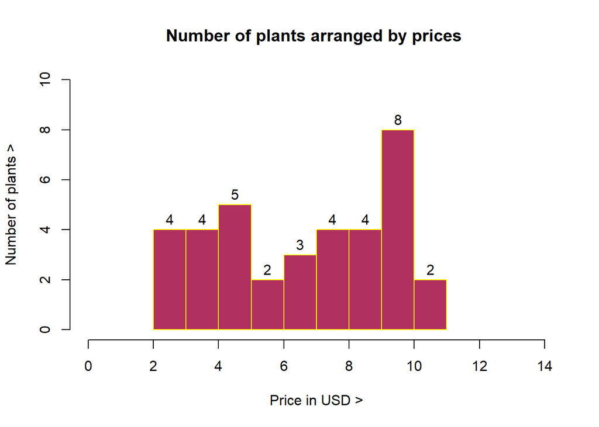

```r
# adorning a histogram by price

h <- hist(xmlDataFrame$RETAIL,
main="Number of plants arranged by prices ",
xlab="Price in USD >",
ylab="Number of plants >",
xlim = c(0,14),
ylim = c(0,10),
col="maroon",
border = "yellow"
)

text(h$mids,h$counts,labels=h$counts, adj=c(0.5, -0.5))
```

### 7. Using sqldf create a SQL query that finds the common names of all plants that cost less than $8 and grow in Sunny light

sqldf library is used for running SQL staements on dataframes. The first argument is a character string representing an SQL select statement or character vector whose components each represent a successive SQL statement to be executed. If this argument is missing then it establishes a connection which subsequent sqldf statements access.

stringsAsFactors is an another argument which if TRUE then those columns output from the database as “character” are converted to “factor” if the heuristic is unable to determine the class. This is of use with categorical variables.

```r
# loading the required package.
if(!require("sqldf")) install.packages("sqldf")
library("sqldf")

join_string <- "select
                COMMON
                from xmlDataFrame
                where RETAIL<8 and LIGHT='Sunny'"

sqldf(join_string, stringsAsFactors = FALSE)
```

| COMMON |
| --- |
| Butterfly Weed |
| Primrose |

### 8. Using dataframe functions to calculate how many plants grow in full shade

I have used a simple sum() function that gives the total number of plants growing in “Shade”.

```r
# sum of all the rows
sum(xmlDataFrame$LIGHT=='Shade')
```

```
## [1] 12
```

### 9. Writing the dataframe to a new table in a new SQLite database using the dbWriteTable function.

A dbWriteTable() function writes, overwrites or appends a data frame to a database table, optionally converting row names to a column and specifying SQL data types for fields. Here, a new database **plantsDB.db** is created which has the table **plantsXML**. Additionally, the columns are modified to lower case.

```r
# installing and loading packages
if (!require("pacman")) install.packages("pacman")
pacman::p_load(pacman, rio, tidyverse)

if (!require("RSQLite")) install.packages("RSQLite")
library(RSQLite)

# connecting to SQLite
con <- dbConnect(RSQLite::SQLite(), "plantsDB.db")

# converting column names to lowercase for simplicity
names(xmlDataFrame)<-tolower(names(xmlDataFrame))

# writing **xmlDataFrame** to **plantsXML** table
write<-dbWriteTable(con, "plantsXML", xmlDataFrame, overwrite=TRUE)
write
```

```
## [1] TRUE
```

```r
# showing all the data from **plantsXML** table
dbGetQuery(con, "SELECT * FROM plantsXML")
```

| common | botanical | zone | light | availability | retail |
| --- | --- | --- | --- | --- | --- |
| Bloodroot | Sanguinaria canadensis | 4 | Mostly Shady | 031599 | 2.543700 |
| Columbine | Aquilegia canadensis | 3 | Mostly Shady | 030699 | 9.768225 |
| Marsh Marigold | Caltha palustris | 4 | Mostly Sunny | 051799 | 7.099425 |
| Cowslip | Caltha palustris | 4 | Mostly Shady | 030699 | 10.320750 |
| Dutchman's-Breeches | Dicentra cucullaria | 3 | Mostly Shady | 012099 | 6.713700 |
| Ginger, Wild | Asarum canadense | 3 | Mostly Shady | 041899 | 9.413775 |
| Hepatica | Hepatica americana | 4 | Mostly Shady | 012699 | 4.639125 |
| Liverleaf | Hepatica americana | 4 | Mostly Shady | 010299 | 4.159575 |
| Jack-In-The-Pulpit | Arisaema triphyllum | 4 | Mostly Shady | 020199 | 3.367275 |
| Mayapple | Podophyllum peltatum | 3 | Mostly Shady | 060599 | 3.106650 |

[output cut: 26 more lines]

### 10. SQLite- inspection of database

On inspection, it is clearly visible that the new database **plantsDB** is created and it has the table **plantsXML**. The columns are correct in lower case as has been done in Task 9 above.

[figure not shown]

Fig 10.1 :plantsDB Database inspection

[figure not shown]

Fig 10.2 :plantsDB Schema in SQLite

Following query is executed from R and it shows the tables present in plantsDB.

```r
# listing all the tables in plantsDB.db
dbListTables(con)
```

```
## [1] "plantsXML"
```

### 11. SQLite- Write a SQL UPDATE statement that decreases all prices by 0.75%.

The update query when executed in SQLite, decreases all the prices by 0.75%.

[figure not shown]

Fig 11.1 :Before UPDATE query is executed in SQLite

[figure not shown]

Fig 11.2 :UPDATE query in SQLite

After updating the rows the price in retail column-

[figure not shown]

Fig 11.2 :After UPDATE query is executed in SQLite

Below is it’s execution from R-

```r
# update query
dbExecute(con, "UPDATE plantsXML SET retail=retail*(1-0.0075)")
```

```
## [1] 36
```

```r
#displaying the modified result
dbGetQuery(con, "SELECT * FROM plantsXML")
```

| common | botanical | zone | light | availability | retail |
| --- | --- | --- | --- | --- | --- |
| Bloodroot | Sanguinaria canadensis | 4 | Mostly Shady | 031599 | 2.524622 |
| Columbine | Aquilegia canadensis | 3 | Mostly Shady | 030699 | 9.694963 |
| Marsh Marigold | Caltha palustris | 4 | Mostly Sunny | 051799 | 7.046179 |
| Cowslip | Caltha palustris | 4 | Mostly Shady | 030699 | 10.243344 |
| Dutchman's-Breeches | Dicentra cucullaria | 3 | Mostly Shady | 012099 | 6.663347 |
| Ginger, Wild | Asarum canadense | 3 | Mostly Shady | 041899 | 9.343172 |
| Hepatica | Hepatica americana | 4 | Mostly Shady | 012699 | 4.604332 |
| Liverleaf | Hepatica americana | 4 | Mostly Shady | 010299 | 4.128378 |
| Jack-In-The-Pulpit | Arisaema triphyllum | 4 | Mostly Shady | 020199 | 3.342020 |
| Mayapple | Podophyllum peltatum | 3 | Mostly Shady | 060599 | 3.083350 |

[output cut: 26 more lines]

### 12. Connecting to the SQLite database from above

After disconnecting the old instance, new connection is established with **plantsDB.db**

```r
# disconnecting the older instance
dbDisconnect(con)

# establishing DB connection
con <- dbConnect(RSQLite::SQLite(), "plantsDB.db")
```

### 13. Executing a SQL query that finds the number of plants by light.

The **plantsXML** table has a **light** attribute (lower case as it was modified in Task 9 above).

```r
# print the count of plants grouped by light
dbGetQuery(con, "SELECT Count(*) As plantCount, light FROM plantsXML GROUP BY light")
```

| plantCount | light |
| --- | --- |
| 13 | Mostly Shady |
| 1 | Mostly Sunny |
| 12 | Shade |
| 1 | Sun |
| 6 | Sun or Shade |
| 3 | Sunny |

### 14. Parse the Plant Catalog XML and write an XPath query that finds all plants that grow in full shade or in full sun.

The parsing of the XML file is being done through xmlParse() function. To write an XPath query in R, xpathSApply() function is used where one parameter is the parsed XML variable. The second argument is the path to extract the required values. **//*[LIGHT=‘Shade’ or LIGHT=‘Sun’]**

```r
# give the input file name- "plants.xml" to the function
result <- xmlParse(file = "plants.xml")

# print the result
print(result)
```

```
## <?xml version="1.0"?>
## <CATALOG>
##   <PLANT>
##     <COMMON>Bloodroot</COMMON>
##     <BOTANICAL>Sanguinaria canadensis</BOTANICAL>
##     <ZONE>4</ZONE>
##     <LIGHT>Mostly Shady</LIGHT>
##     <PRICE>$2.44</PRICE>
##     <AVAILABILITY>031599</AVAILABILITY>
##   </PLANT>
##   <PLANT>
##     <COMMON>Columbine</COMMON>
##     <BOTANICAL>Aquilegia canadensis</BOTANICAL>
##     <ZONE>3</ZONE>
##     <LIGHT>Mostly Shady</LIGHT>
##     <PRICE>$9.37</PRICE>
##     <AVAILABILITY>030699</AVAILABILITY>
##   </PLANT>
##   <PLANT>
##     <COMMON>Marsh Marigold</COMMON>
##     <BOTANICAL>Caltha palustris</BOTANICAL>
##     <ZONE>4</ZONE>
##     <LIGHT>Mostly Sunny</LIGHT>
##     <PRICE>$6.81</PRICE>
##     <AVAILABILITY>051799</AVAILABILITY>
##   </PLANT>
##   <PLANT>
##     <COMMON>Cowslip</COMMON>
##     <BOTANICAL>Caltha palustris</BOTANICAL>
##     <ZONE>4</ZONE>
##     <LIGHT>Mostly Shady</LIGHT>
##     <PRICE>$9.90</PRICE>
##     <AVAILABILITY>030699</AVAILABILITY>
##   </PLANT>
##   <PLANT>
##     <COMMON>Dutchman's-Breeches</COMMON>
##     <BOTANICAL>Dicentra cucullaria</BOTANICAL>
##     <ZONE>3</ZONE>
##     <LIGHT>Mostly Shady</LIGHT>
##     <PRICE>$6.44</PRICE>
```

[output cut: 237 more lines]

```
##     <ZONE>Annual</ZONE>
##     <LIGHT>Shade</LIGHT>
##     <PRICE>$5.63</PRICE>
##     <AVAILABILITY>071199</AVAILABILITY>
##   </PLANT>
##   <PLANT>
##     <COMMON>Cardinal Flower</COMMON>
##     <BOTANICAL>Lobelia cardinalis</BOTANICAL>
##     <ZONE>2</ZONE>
##     <LIGHT>Shade</LIGHT>
##     <PRICE>$3.02</PRICE>
##     <AVAILABILITY>022299</AVAILABILITY>
##   </PLANT>
## </CATALOG>
##
```

```r
# applying XPath query
partialRes<- xpathSApply(result,"//*[LIGHT='Shade' or LIGHT='Sun']")

# print the partial result
partialRes
```

```
## [[1]]
## <PLANT>
##   <COMMON>Violet, Dog-Tooth</COMMON>
##   <BOTANICAL>Erythronium americanum</BOTANICAL>
##   <ZONE>4</ZONE>
##   <LIGHT>Shade</LIGHT>
##   <PRICE>$9.04</PRICE>
##   <AVAILABILITY>020199</AVAILABILITY>
## </PLANT>
##
## [[2]]
## <PLANT>
##   <COMMON>Trout Lily</COMMON>
##   <BOTANICAL>Erythronium americanum</BOTANICAL>
##   <ZONE>4</ZONE>
##   <LIGHT>Shade</LIGHT>
##   <PRICE>$6.94</PRICE>
##   <AVAILABILITY>032499</AVAILABILITY>
## </PLANT>
##
## [[3]]
## <PLANT>
##   <COMMON>Adder's-Tongue</COMMON>
##   <BOTANICAL>Erythronium americanum</BOTANICAL>
##   <ZONE>4</ZONE>
##   <LIGHT>Shade</LIGHT>
##   <PRICE>$9.58</PRICE>
##   <AVAILABILITY>041399</AVAILABILITY>
## </PLANT>
##
## [[4]]
## <PLANT>
##   <COMMON>Bee Balm</COMMON>
##   <BOTANICAL>Monarda didyma</BOTANICAL>
##   <ZONE>4</ZONE>
##   <LIGHT>Shade</LIGHT>
##   <PRICE>$4.59</PRICE>
##   <AVAILABILITY>050399</AVAILABILITY>
## </PLANT>
##
```

[output cut: 74 more lines]

```
##   <ZONE>Annual</ZONE>
##   <LIGHT>Shade</LIGHT>
##   <PRICE>$5.63</PRICE>
##   <AVAILABILITY>071199</AVAILABILITY>
## </PLANT>
##
## [[13]]
## <PLANT>
##   <COMMON>Cardinal Flower</COMMON>
##   <BOTANICAL>Lobelia cardinalis</BOTANICAL>
##   <ZONE>2</ZONE>
##   <LIGHT>Shade</LIGHT>
##   <PRICE>$3.02</PRICE>
##   <AVAILABILITY>022299</AVAILABILITY>
## </PLANT>
```

### 15. Put the result from the previous XPath query into a dataframe and then calculate the 10% trimmed mean of the prices.

The previous query stores the XML object in partialRes variable. This variable then is used to transform to data frame as a parameter of xmlToDataFrame() function.

Trimmed means are robust estimators of central tendency. To compute a trimmed mean, we remove a predetermined amount of observations on each side of a distribution, and average the remaining observations.

**Trimmed Mean steps-**

1. Sort the numeric values in the column to be trimmed.
2. The number of observations to remove is **floor(0.1 * total_observation)**. So we trim these many observations from each end.
3. We take the mean of the remaining observations.

In R, all this is implemented in a mean() function with a parameter **trim** set to some decimal value.

```r
# transforming the XML to dataframe
partialDataFrame <- xmlToDataFrame(partialRes)

# print the result
partialDataFrame
```

| COMMON | BOTANICAL | ZONE | LIGHT | PRICE | AVAILABILITY |
| --- | --- | --- | --- | --- | --- |
| Violet, Dog-Tooth | Erythronium americanum | 4 | Shade | $9.04 | 020199 |
| Trout Lily | Erythronium americanum | 4 | Shade | $6.94 | 032499 |
| Adder's-Tongue | Erythronium americanum | 4 | Shade | $9.58 | 041399 |
| Bee Balm | Monarda didyma | 4 | Shade | $4.59 | 050399 |
| Bergamot | Monarda didyma | 4 | Shade | $7.16 | 042799 |
| Buttercup | Ranunculus | 4 | Shade | $2.57 | 061099 |
| Crowfoot | Ranunculus | 4 | Shade | $9.34 | 040399 |
| Cinquefoil | Potentilla | Annual | Shade | $7.06 | 052599 |
| Jacob's Ladder | Polemonium caeruleum | Annual | Shade | $9.26 | 022199 |
| Greek Valerian | Polemonium caeruleum | Annual | Shade | $4.36 | 071499 |

[output cut: 3 more lines]

```r
# calulation of 10% trimmed mean
mean(as.numeric(substring(partialDataFrame$PRICE,2)), trim=0.1)
```

```
## [1] 6.753636
```